# 1. Descripción de la estación

La estación pluviométrica COPIAPO, administrada por DGA, se localiza en la Región DE ATACAMA, a una latitud de -27.36° y longitud -70.34°, con una elevación aproximada de 385 m s.n.m.. La estación registra la variable precipitación diaria (mm/día) y cuenta con una serie de datos que se extiende desde el 1971-01-01 hasta el 2025-05-31 , totalizando 19875 días en el período de análisis. De estos, 18643 días presentan registros válidos, lo que corresponde a una cobertura del 93.8%, sin detección de valores atípicos.

#2. Descripción de metricas

## 1. Curva de Variación Estacional (CVE)

La **Curva de Variación Estacional (CVE)** representa la distribución intra–anual de la **precipitación mensual acumulada** a lo largo del año hidrológico, permitiendo identificar el régimen estacional de las lluvias y los períodos húmedos y secos predominantes.

Sea $RR_{i,j}$ la precipitación mensual acumulada del mes $i$ en el año hidrológico $j$, con $i = 1, \dots, 12$. La precipitación media mensual acumulada se define como:

$$\overline{RR}_i = \frac{1}{N} \sum_{j=1}^{N} RR_{i,j}$$

donde $N$ es el número de años hidrológicos con información válida.

La CVE se obtiene graficando $\overline{RR}_i$ en función del mes hidrológico, ordenado desde abril hasta marzo. Esta curva permite:

- Identificar la concentración temporal de la precipitación.
- Reconocer el mes o período de mayor aporte pluviométrico.
- Comparar el comportamiento estacional entre estaciones o cuencas.

## 2. Estadísticos Mensuales de la Precipitación (Media, Desviación Estándar y Coeficiente de Variación)

Con el objetivo de caracterizar la variabilidad interanual de la precipitación mensual, se calculan los principales estadísticos descriptivos para cada mes hidrológico.

La **media mensual** se define como:

$$\overline{RR}_i = \frac{1}{N} \sum_{j=1}^{N} RR_{i,j}$$

La **desviación estándar mensual**, que cuantifica la dispersión de los valores respecto a la media, se calcula como:

$$\sigma_i = \sqrt{\frac{1}{N-1} \sum_{j=1}^{N} \left(RR_{i,j} -
\overline{RR}_i\right)^2}$$

Finalmente, el **coeficiente de variación (CV)**, utilizado como una medida adimensional de la variabilidad relativa, se define como:

$$CV_i = \frac{\sigma_i}{\overline{RR}_i}$$

Valores elevados de $CV_i$ indican una alta variabilidad interanual de la precipitación mensual, característica común en climas áridos y semiáridos.

## 3. Índice de Estacionalidad de la Precipitación (Índice de Markham)

El **Índice de Estacionalidad de Markham (SI)** cuantifica el grado de concentración temporal de la precipitación anual y permite, adicionalmente, identificar el momento del año en que dicha precipitación se concentra. A diferencia de otros índices de estacionalidad, este método representa la precipitación mensual como vectores angulares distribuidos uniformemente a lo largo del ciclo anual.

Sea $P_m$ la precipitación total del mes $m$ en un año hidrológico, con $m = 1, \dots, 12$, y sea $P_{anual}$ la precipitación total anual, definida como:

$$P_{anual} = \sum_{m=1}^{12} P_m$$

A cada mes se le asigna un ángulo $\theta_m$ en el círculo anual, definido como:

$$\theta_m = \frac{2\pi}{12}(m - 1)$$

La precipitación mensual se representa como un vector de magnitud $P_m$ y dirección $\theta_m$. Las componentes del vector resultante anual se calculan como:

$$X = \sum_{m=1}^{12} P_m \cos(\theta_m)$$

$$Y = \sum_{m=1}^{12} P_m \sin(\theta_m)$$

El **Índice de Estacionalidad de Markham** se define como la magnitud del vector resultante normalizada por la precipitación anual:

$$SI = \frac{\sqrt{X^2 + Y^2}}{P_{anual}}$$

Este índice es adimensional y toma valores comprendidos entre 0 y 1, donde valores cercanos a 0 indican una distribución uniforme de la precipitación a lo largo del año, mientras que valores cercanos a 1 reflejan una fuerte concentración de la precipitación en un período reducido del año.

Adicionalmente, la **fase estacional** o mes dominante de la precipitación se obtiene a partir del ángulo del vector resultante:

$$\phi = \arctan\left(\frac{Y}{X}\right)$$

La fase $\phi$ permite identificar el mes o estación del año en la cual se concentra el mayor aporte pluviométrico.

# 3.Resultados

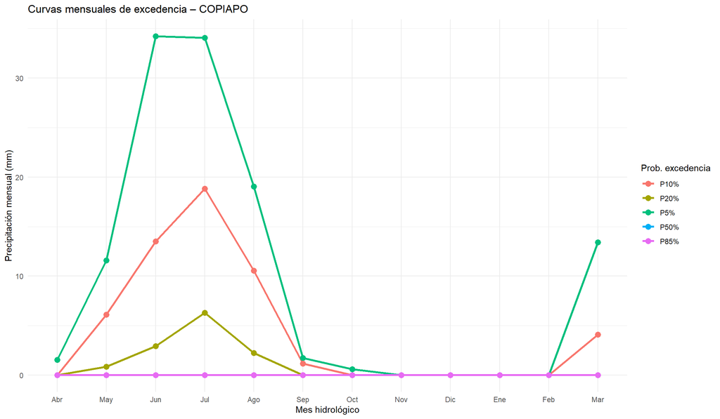

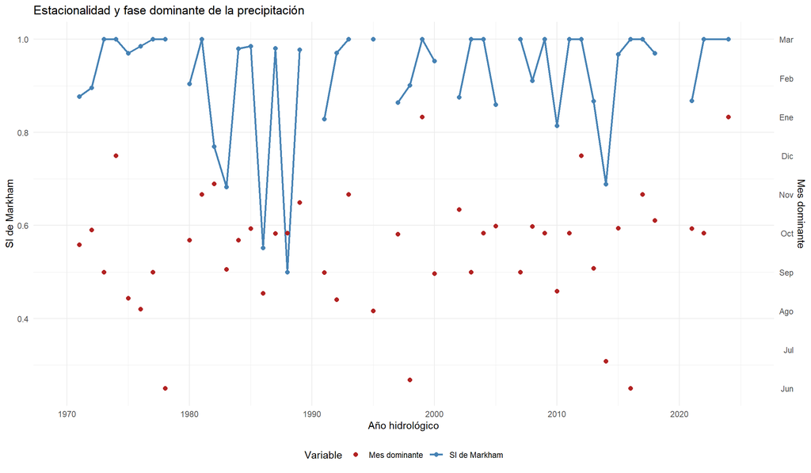

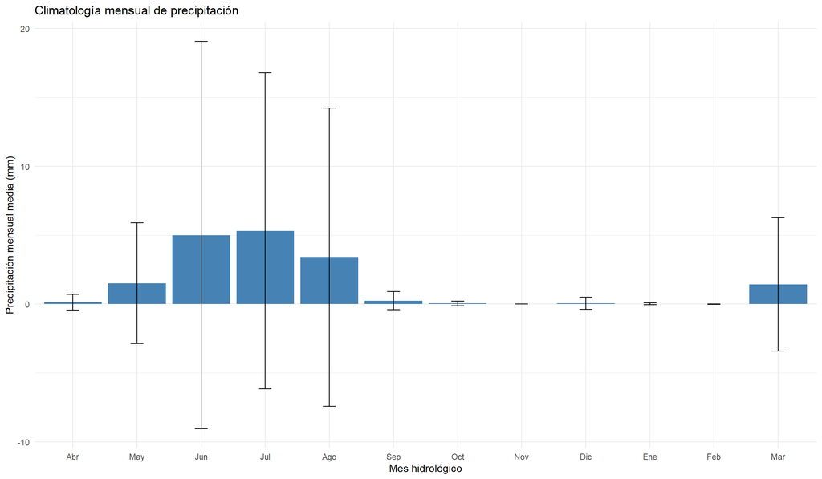